# Random Forest Classifier

Langkah pertama yang dilakukan adalah mengatur working directory pada R, serta tempatkan data yang tersedia pada file ini.

```r
setwd("D:\\DS\\R\\[R] Random Forest Classifier")
getwd()
```

```
## [1] "D:/DS/R/[R] Random Forest Classifier"
```

```r
rm(list=ls(all=TRUE))
```

```r
##Input Data
telco <- read.csv("telco.csv", header = T)
head(telco)
```

```
##   UpdatedAt  customerID gender SeniorCitizen Partner tenure PhoneService
## 1    202006 45759018157 Female            No     Yes      1           No
## 2    202006 45315483266   Male            No     Yes     60          Yes
## 3    202006 45236961615   Male            No      No      5          Yes
## 4    202006 45929827382 Female            No     Yes     72          Yes
## 5    202006 45305082233 Female            No     Yes     56          Yes
## 6    202006 45072364214   Male            No      No     44          Yes
##   StreamingTV InternetService PaperlessBilling MonthlyCharges TotalCharges
## 1          No             Yes              Yes          29.85        29.85
## 2          No              No              Yes          20.50      1198.80
## 3         Yes             Yes               No         104.10       541.90
## 4         Yes             Yes              Yes         115.50      8312.75
## 5         Yes             Yes               No          81.25      4620.40
## 6         Yes             Yes              Yes          85.25      3704.15
##   Churn
## 1    No
## 2    No
## 3   Yes
## 4    No
## 5    No
## 6    No
```

Karena variabel CustomerID bersifat unik dan tidak dapat digunakan, maka variabel ini dihilangkan terlebih dahulu dari dataset, sebagai berikut :

```r
telco <-telco[,-c(1:2)]
head(telco)
```

```
##   gender SeniorCitizen Partner tenure PhoneService StreamingTV InternetService
## 1 Female            No     Yes      1           No          No             Yes
## 2   Male            No     Yes     60          Yes          No              No
## 3   Male            No      No      5          Yes         Yes             Yes
## 4 Female            No     Yes     72          Yes         Yes             Yes
## 5 Female            No     Yes     56          Yes         Yes             Yes
## 6   Male            No      No     44          Yes         Yes             Yes
##   PaperlessBilling MonthlyCharges TotalCharges Churn
## 1              Yes          29.85        29.85    No
## 2              Yes          20.50      1198.80    No
## 3               No         104.10       541.90   Yes
## 4              Yes         115.50      8312.75    No
## 5               No          81.25      4620.40    No
## 6              Yes          85.25      3704.15    No
```

## Eksplorasi Data

Langkah selanjutnya adalah melakukan eksplorasi terhadap dataset, sebagai berikut :

```r
#Melihat struktur data
str(telco)
```

```
## 'data.frame':    6950 obs. of  11 variables:
##  $ gender          : Factor w/ 2 levels "Female","Male": 1 2 2 1 1 2 2 2 1 2 ...
##  $ SeniorCitizen   : Factor w/ 2 levels "No","Yes": 1 1 1 1 1 1 1 1 1 1 ...
##  $ Partner         : Factor w/ 2 levels "No","Yes": 2 2 1 2 2 1 2 2 2 2 ...
##  $ tenure          : int  1 60 5 72 56 44 39 12 71 19 ...
##  $ PhoneService    : Factor w/ 2 levels "No","Yes": 1 2 2 2 2 2 2 2 2 2 ...
##  $ StreamingTV     : Factor w/ 2 levels "No","Yes": 1 1 2 2 2 2 2 1 1 1 ...
##  $ InternetService : Factor w/ 2 levels "No","Yes": 2 1 2 2 2 2 2 2 1 1 ...
##  $ PaperlessBilling: Factor w/ 2 levels "No","Yes": 2 2 1 2 1 2 1 2 1 1 ...
##  $ MonthlyCharges  : num  29.9 20.5 104.1 115.5 81.2 ...
##  $ TotalCharges    : num  29.9 1198.8 541.9 8312.8 4620.4 ...
##  $ Churn           : Factor w/ 2 levels "No","Yes": 1 1 2 1 1 1 2 1 1 1 ...
```

Dari struktur data diatas, terlihat bahwa data sudah sesuai dengan type data dari masing - masing variabel, untuk variabel kategorik data bertipe factor, untuk variabel non-kategorik data bertipe integer/numerik.

```r
#Melihat apakah ada missing data
summary(telco)
```

```
##     gender     SeniorCitizen Partner        tenure       PhoneService
##  Female:3445   No :5822      No :3591   Min.   :  0.00   No : 669
##  Male  :3505   Yes:1128      Yes:3359   1st Qu.:  9.00   Yes:6281
##                                         Median : 29.00
##                                         Mean   : 32.42
##                                         3rd Qu.: 55.00
##                                         Max.   :124.00
##  StreamingTV InternetService PaperlessBilling MonthlyCharges    TotalCharges
##  No :4279    No :1505        No :2836         Min.   :  0.00   Min.   :  19
##  Yes:2671    Yes:5445        Yes:4114         1st Qu.: 36.46   1st Qu.: 407
##                                               Median : 70.45   Median :1401
##                                               Mean   : 64.99   Mean   :2286
##                                               3rd Qu.: 89.85   3rd Qu.:3800
##                                               Max.   :169.93   Max.   :8889
##  Churn
##  No :5114
##  Yes:1836
##
##
##
##
```

```r
table(is.na(telco))
```

```
##
## FALSE
## 76450
```

Terlihat bahwa tidak terdapat missing data pada dataset. Selanjutnya adalah membuat pie chart untuk variabel Churn, sebagai berikut :

```
## # A tibble: 2 x 2
##   Churn Total
##   <fct> <int>
## 1 No     5114
## 2 Yes    1836
```

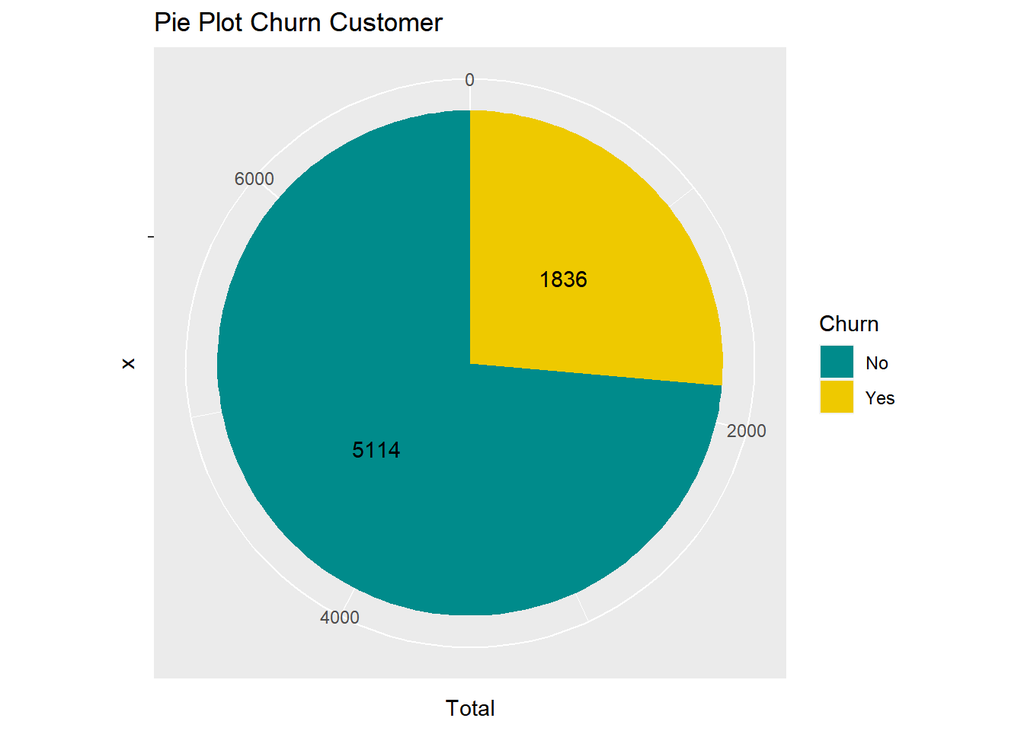

```r
#Pie Plot Variabel Churn
library(dplyr)
df_churn <- telco %>%
  select(Churn) %>%
  group_by(Churn) %>%
  summarise(Total = n())
df_churn
```

## Split Data

Langkah selanjutnya adalah membagi data ke dalam Training data dan Testing data, sebagai berikut :

```r
##Split Data
library(caTools)
set.seed(123)
Split <- sample.split(telco, SplitRatio = 0.7)
Train <- subset(telco, Split==TRUE)
Test <- subset(telco, Split==FALSE)
```

## Modeling Train Data (Default Parameter)

```r
##Modeling Train Data (default parameter)
library(randomForest)
set.seed(222)
rf_model1<-randomForest(Churn~., data = Train)
rf_model1
```

```
##
## Call:
##  randomForest(formula = Churn ~ ., data = Train)
##                Type of random forest: classification
##                      Number of trees: 500
## No. of variables tried at each split: 3
##
##         OOB estimate of  error rate: 20.48%
## Confusion matrix:
##       No Yes class.error
## No  3005 277  0.08439976
## Yes  629 512  0.55127082
```

Langkah selanjutnya adalah melakukan prediksi pada Testing data dengan menggunakan Training model, sebagai berikut :

```r
##Predict (default parameter)
library(caret)
p1_test <- predict(rf_model1, newdata = Test)
p1_test_cm<-confusionMatrix(p1_test, Test$Churn)
p1_test_cm
```

```
## Confusion Matrix and Statistics
##
##           Reference
## Prediction   No  Yes
##        No  1655  370
##        Yes  177  325
##
##                Accuracy : 0.7835
##                  95% CI : (0.767, 0.7995)
##     No Information Rate : 0.725
##     P-Value [Acc > NIR] : 8.416e-12
##
##                   Kappa : 0.406
##
##  Mcnemar's Test P-Value : 2.224e-16
##
##             Sensitivity : 0.9034
##             Specificity : 0.4676
##          Pos Pred Value : 0.8173
##          Neg Pred Value : 0.6474
##              Prevalence : 0.7250
##          Detection Rate : 0.6549
##    Detection Prevalence : 0.8013
##       Balanced Accuracy : 0.6855
##
##        'Positive' Class : No
##
```

## Tuning Parameter

Langkah selanjutnya adalah mencari nilai parameter mtry yang optimal untuk model random forest, ada beberapa cara untuk mencari parameter mtry yang optimal yakni sebagai berikut :

### RandomSearch CV

```r
#Random Search CV
set.seed(222)
control <- trainControl(method = "repeatedcv",
                        number = 10,
                        repeats = 3,
                        search = "random")
rf_random <- train(Churn~.,
                   data = telco,
                   method = "rf",
                   metric = "Accuracy",
                   tuneLength = 10,
                   trControl = control)
rf_random
```

```
## Random Forest
##
## 6950 samples
##   10 predictor
##    2 classes: 'No', 'Yes'
##
## No pre-processing
## Resampling: Cross-Validated (10 fold, repeated 3 times)
## Summary of sample sizes: 6256, 6256, 6256, 6254, 6256, 6254, ...
## Resampling results across tuning parameters:
##
##   mtry  Accuracy   Kappa
##    2    0.7951543  0.3987911
##    4    0.7833086  0.3953396
##    6    0.7769782  0.3837060
##    7    0.7764493  0.3824825
##    8    0.7756830  0.3821310
##    9    0.7743879  0.3782746
##   10    0.7743385  0.3794617
##
## Accuracy was used to select the optimal model using the largest value.
## The final value used for the model was mtry = 2.
```

Dengan metode ini diperoleh best mtry adalah 2.

### GridSearch CV

```r
#Grid Search CV
control <- trainControl(method ="repeatedcv",
                        number = 10,
                        repeats = 3,
                        search = "grid")
set.seed(222)
tunegrid <- expand.grid(.mtry=c(1:10))
rf_gridsearch <- train(Churn~.,
                       data = telco,
                       method = "rf",
                       metric = "Accuracy",
                       tuneGrid = tunegrid,
                       trControl = control)
rf_gridsearch
```

```
## Random Forest
##
## 6950 samples
##   10 predictor
##    2 classes: 'No', 'Yes'
##
## No pre-processing
## Resampling: Cross-Validated (10 fold, repeated 3 times)
## Summary of sample sizes: 6256, 6256, 6256, 6254, 6256, 6254, ...
## Resampling results across tuning parameters:
##
##   mtry  Accuracy   Kappa
##    1    0.7574560  0.1345038
##    2    0.7939545  0.3952879
##    3    0.7930936  0.4115954
##    4    0.7833084  0.3944844
##    5    0.7789922  0.3882772
##    6    0.7773612  0.3864893
##    7    0.7754420  0.3800425
##    8    0.7759223  0.3817688
##    9    0.7744354  0.3794570
##   10    0.7745316  0.3797799
##
## Accuracy was used to select the optimal model using the largest value.
## The final value used for the model was mtry = 2.
```

Dengan metode ini diperoleh best mtry adalah 2.

### TuneRF

```
## mtry = 3  OOB error = 20.48%
## Searching left ...
## mtry = 2     OOB error = 20.08%
## 0.01986755 0.05
## Searching right ...
## mtry = 4     OOB error = 21.34%
## -0.0419426 0.05
```

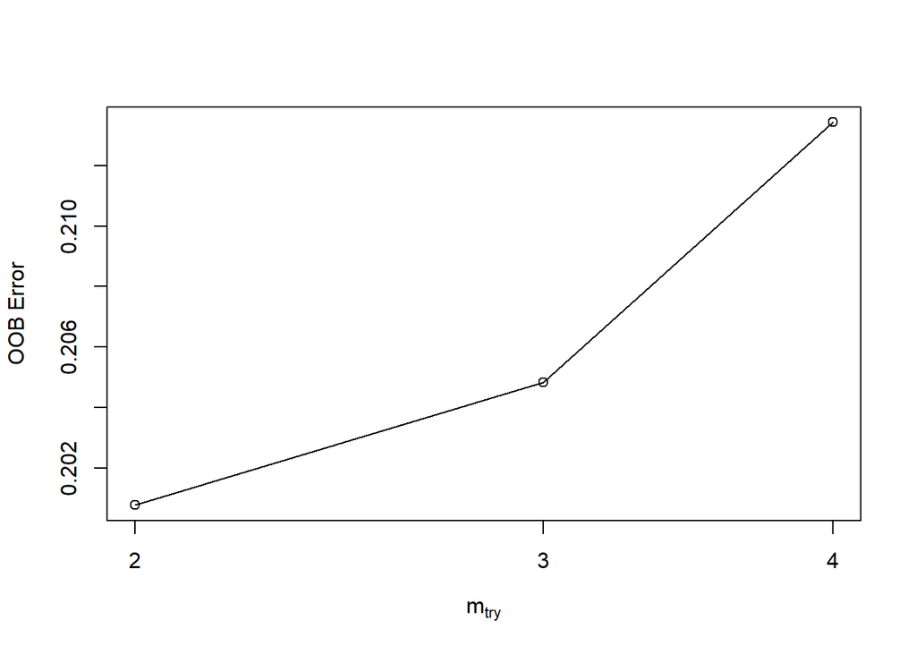

Dengan metode ini diperoleh best mtry adalah 2.

Untuk mtry = 3 sudah dimodelkan pada model dengan default parameter, selanjutnya adalah memodelkan dengan mtry = 2 sebagai berikut :

```r
##Modeling Train Data (mtry=2)
library(randomForest)
set.seed(222)
rf_model2<-randomForest(Churn~., data = Train, mtry=2)
rf_model2
```

```
##
## Call:
##  randomForest(formula = Churn ~ ., data = Train, mtry = 2)
##                Type of random forest: classification
##                      Number of trees: 500
## No. of variables tried at each split: 2
##
##         OOB estimate of  error rate: 20.12%
## Confusion matrix:
##       No Yes class.error
## No  3071 211  0.06429007
## Yes  679 462  0.59509202
```

```r
##Predict (mtry=2)
library(caret)
p2_test <- predict(rf_model2, newdata = Test)
p2_test_cm<-confusionMatrix(p2_test, Test$Churn)
p2_test_cm
```

```
## Confusion Matrix and Statistics
##
##           Reference
## Prediction   No  Yes
##        No  1691  402
##        Yes  141  293
##
##                Accuracy : 0.7851
##                  95% CI : (0.7686, 0.801)
##     No Information Rate : 0.725
##     P-Value [Acc > NIR] : 2.275e-12
##
##                   Kappa : 0.3901
##
##  Mcnemar's Test P-Value : < 2.2e-16
##
##             Sensitivity : 0.9230
##             Specificity : 0.4216
##          Pos Pred Value : 0.8079
##          Neg Pred Value : 0.6751
##              Prevalence : 0.7250
##          Detection Rate : 0.6692
##    Detection Prevalence : 0.8283
##       Balanced Accuracy : 0.6723
##
##        'Positive' Class : No
##
```

Dapat dilihat bahwa dengan mtry = 2 diperoleh nilai Accuracy-nya lebih besar dibanding dengan mtry = 3 pada model default parameter. Sehingga model yang dipilih adalah dengan mtry = 2.

## Handling Imbalanced Data

Selanjutnya, pada model mtry = 2 dapat dilihat bahwa dari model random forest dengan mtry = 2 diperoleh nilai Sensitivity dan Spesificity yang diperoleh jauh berbeda.Hal ini dikarenakan adanya permasalahan data tidak seimbang, dimana pada variabel Churn, terlihat bahwa customer yang memilih Churn (Yes = 1836) lebih sedikit dibanding customer yang memilih untuk tidak churn (No = 5114).

Ada beberapa cara untuk mengatasi masalah ini, yakni sebagai berikut :

### OverSampling

```r
##Mengatasi spesificity yang rendah karena imbalance data
library(ROSE)
##OverSampling
table(Train$Churn)
```

```
##
##   No  Yes
## 3282 1141
```

```r
3286*2
```

```
## [1] 6572
```

```r
over <- ovun.sample(Churn~., data = Train, method = "over", N=6572)$data
table(over$Churn)
```

```
##
##   No  Yes
## 3282 3290
```

```r
#Modeling Train Data (oversampling)
library(randomForest)
set.seed(222)
rf_model2_over<-randomForest(Churn~., data = over, mtry=2)
rf_model2_over
```

```
##
## Call:
##  randomForest(formula = Churn ~ ., data = over, mtry = 2)
##                Type of random forest: classification
##                      Number of trees: 500
## No. of variables tried at each split: 2
##
##         OOB estimate of  error rate: 19%
## Confusion matrix:
##       No  Yes class.error
## No  2461  821   0.2501523
## Yes  428 2862   0.1300912
```

```r
#Predict (oversampling)
library(caret)
p2_test_over <- predict(rf_model2_over, newdata = Test)
p2_test_over_cm<-confusionMatrix(p2_test_over, Test$Churn)
p2_test_over_cm
```

```
## Confusion Matrix and Statistics
##
##           Reference
## Prediction   No  Yes
##        No  1345  177
##        Yes  487  518
##
##                Accuracy : 0.7372
##                  95% CI : (0.7196, 0.7543)
##     No Information Rate : 0.725
##     P-Value [Acc > NIR] : 0.08665
##
##                   Kappa : 0.4212
##
##  Mcnemar's Test P-Value : < 2e-16
##
##             Sensitivity : 0.7342
##             Specificity : 0.7453
##          Pos Pred Value : 0.8837
##          Neg Pred Value : 0.5154
##              Prevalence : 0.7250
##          Detection Rate : 0.5323
##    Detection Prevalence : 0.6023
##       Balanced Accuracy : 0.7397
##
##        'Positive' Class : No
##
```

### UnderSampling

```r
##UnderSampling
1137*2
```

```
## [1] 2274
```

```r
under <- ovun.sample(Churn~., data = Train, method = "under", N=2274)$data
table(under$Churn)
```

```
##
##   No  Yes
## 1133 1141
```

```r
#Modeling Train Data (undersampling)
library(randomForest)
set.seed(222)
rf_model2_under<-randomForest(Churn~., data = under, mtry=2)
rf_model2_under
```

```
##
## Call:
##  randomForest(formula = Churn ~ ., data = under, mtry = 2)
##                Type of random forest: classification
##                      Number of trees: 500
## No. of variables tried at each split: 2
##
##         OOB estimate of  error rate: 25.81%
## Confusion matrix:
##      No Yes class.error
## No  806 327   0.2886143
## Yes 260 881   0.2278703
```

```r
#Predict (undersampling)
library(caret)
p2_test_under <- predict(rf_model2_under, newdata = Test)
p2_test_under_cm<-confusionMatrix(p2_test_under, Test$Churn)
p2_test_under_cm
```

```
## Confusion Matrix and Statistics
##
##           Reference
## Prediction   No  Yes
##        No  1283  156
##        Yes  549  539
##
##                Accuracy : 0.721
##                  95% CI : (0.7031, 0.7384)
##     No Information Rate : 0.725
##     P-Value [Acc > NIR] : 0.681
##
##                   Kappa : 0.4048
##
##  Mcnemar's Test P-Value : <2e-16
##
##             Sensitivity : 0.7003
##             Specificity : 0.7755
##          Pos Pred Value : 0.8916
##          Neg Pred Value : 0.4954
##              Prevalence : 0.7250
##          Detection Rate : 0.5077
##    Detection Prevalence : 0.5694
##       Balanced Accuracy : 0.7379
##
##        'Positive' Class : No
##
```

### SMOTE

```r
##SMOTE
table(Train$Churn)
```

```
##
##   No  Yes
## 3282 1141
```

```r
library(DMwR)
smote <- SMOTE(Churn~. , data =  Train, perc.over = 100, perc.under = 200)
table(smote$Churn)
```

```
##
##   No  Yes
## 2282 2282
```

```r
#Modeling Train Data (smote)
library(randomForest)
set.seed(222)
rf_model2_smote<-randomForest(Churn~., data = smote, mtry=2)
rf_model2_smote
```

```
##
## Call:
##  randomForest(formula = Churn ~ ., data = smote, mtry = 2)
##                Type of random forest: classification
##                      Number of trees: 500
## No. of variables tried at each split: 2
##
##         OOB estimate of  error rate: 21.69%
## Confusion matrix:
##       No  Yes class.error
## No  1776  506   0.2217353
## Yes  484 1798   0.2120947
```

```r
#Predict (smote)
library(caret)
p2_test_smote<- predict(rf_model2_smote, newdata = Test)
p2_test_smote_cm<-confusionMatrix(p2_test_smote, Test$Churn)
p2_test_smote_cm
```

```
## Confusion Matrix and Statistics
##
##           Reference
## Prediction   No  Yes
##        No  1295  174
##        Yes  537  521
##
##                Accuracy : 0.7186
##                  95% CI : (0.7007, 0.7361)
##     No Information Rate : 0.725
##     P-Value [Acc > NIR] : 0.7693
##
##                   Kappa : 0.3928
##
##  Mcnemar's Test P-Value : <2e-16
##
##             Sensitivity : 0.7069
##             Specificity : 0.7496
##          Pos Pred Value : 0.8816
##          Neg Pred Value : 0.4924
##              Prevalence : 0.7250
##          Detection Rate : 0.5125
##    Detection Prevalence : 0.5813
##       Balanced Accuracy : 0.7283
##
##        'Positive' Class : No
##
```

## Evaluasi Model

```r
library(pROC)
auc<- roc(Test$Churn, factor(p2_test, ordered =  TRUE))
auc
```

```
##
## Call:
## roc.default(response = Test$Churn, predictor = factor(p2_test,     ordered = TRUE))
##
## Data: factor(p2_test, ordered = TRUE) in 1832 controls (Test$Churn No) < 695 cases (Test$Churn Yes).
## Area under the curve: 0.6723
```

```r
auc_over <- roc(Test$Churn, factor(p2_test_over, ordered =  TRUE))
auc_over
```

```
##
## Call:
## roc.default(response = Test$Churn, predictor = factor(p2_test_over,     ordered = TRUE))
##
## Data: factor(p2_test_over, ordered = TRUE) in 1832 controls (Test$Churn No) < 695 cases (Test$Churn Yes).
## Area under the curve: 0.7397
```

```r
auc_under <- roc(Test$Churn, factor(p2_test_under, ordered =  TRUE))
auc_under
```

```
##
## Call:
## roc.default(response = Test$Churn, predictor = factor(p2_test_under,     ordered = TRUE))
##
## Data: factor(p2_test_under, ordered = TRUE) in 1832 controls (Test$Churn No) < 695 cases (Test$Churn Yes).
## Area under the curve: 0.7379
```

```r
auc_smote <- roc(Test$Churn, factor(p2_test_smote, ordered =  TRUE))
auc_smote
```

```
##
## Call:
## roc.default(response = Test$Churn, predictor = factor(p2_test_smote,     ordered = TRUE))
##
## Data: factor(p2_test_smote, ordered = TRUE) in 1832 controls (Test$Churn No) < 695 cases (Test$Churn Yes).
## Area under the curve: 0.7283
```

Berikut tabel ringkasan, untuk evaulasi keempat model diatas:

```r
nama_metode<-c("Tanpa Handling", "OverSampling", "UnderSampling", "SMOTE")
accuracy <- c(p2_test_cm$overall[1], p2_test_over_cm$overall[1], p2_test_under_cm$overall[1], p2_test_smote_cm$overall[1])
sensitivity <- c(p2_test_cm$overall[2], p2_test_over_cm$overall[2], p2_test_under_cm$overall[2], p2_test_smote_cm$overall[2])
specitifity <- c(p2_test_cm$overall[3], p2_test_over_cm$overall[3], p2_test_under_cm$overall[3], p2_test_smote_cm$overall[3])
auc <- c(auc$auc, auc_over$auc, auc_under$auc, auc_smote$auc)
data.frame(nama_metode, accuracy, sensitivity, specitifity, auc)
```

[output not shown]

## Importance Variable

Selanjutnya akan dilihat variabel mana yang paling penting dalam memengaruhi customer untuk Churn, yakni sebagai berikut :

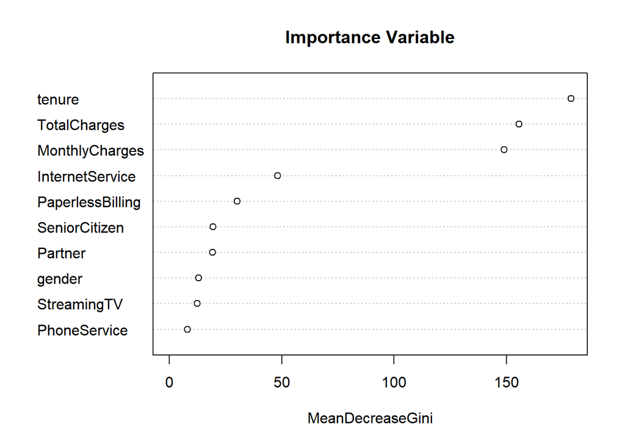

Terlihat bahwa variabel yang paling berpengaruh terhadap keputusan customer untuk Churn adalah tenure, TotalCharges dan MonthlyCharges.